# Analogous PT analysis

## Plots

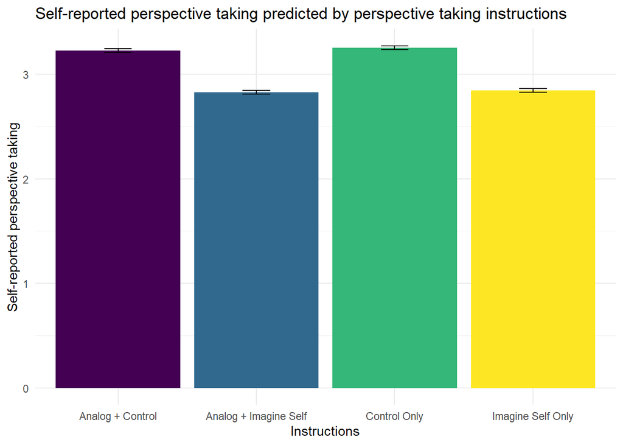

```r
ggplot(pt_cond, aes(condition, mean, fill = condition)) +
  geom_bar(stat = "identity") +
  theme_minimal() +
  theme(legend.position = "none") +
  labs(title = "Self-reported perspective taking predicted by perspective taking instructions",
       x = "Instructions",
       y = "Self-reported perspective taking") +
  geom_errorbar(aes(ymin = mean - se, ymax = mean + se), width = .2,
                position = position_dodge(.9)) +
  scale_fill_viridis_d()
```

Results indicate that people in the imagine-self conditions report taking the perspective of their out-group target less than those who are in the control group, regardless of analogous instructions. Possibly a back firing effect due to threat? The more you are told to consider the perspective of an out-group target, the less you want to.

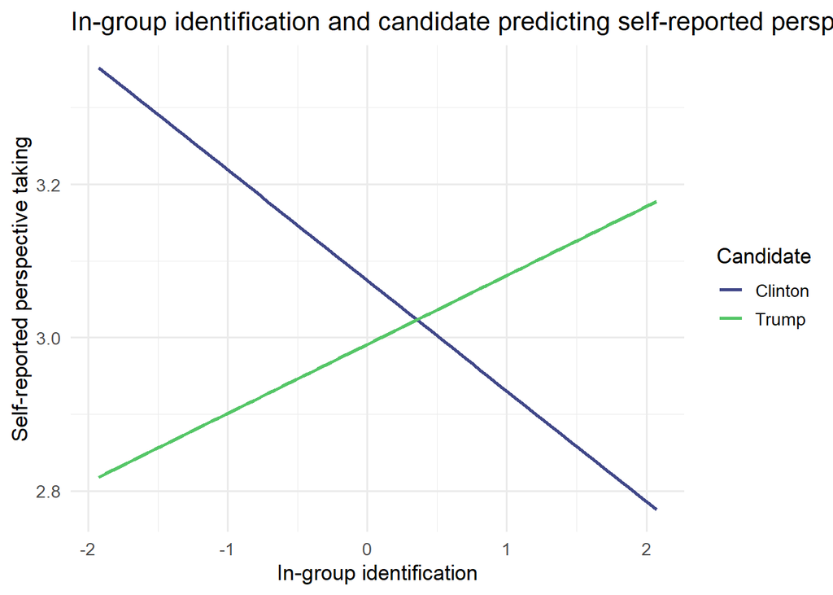

```r
ptxidentxcand <- data_clean %>%
  select(ident_c, pt_mancheck, cand_pref, ID) %>%
  mutate(cand_pref = recode(cand_pref, "'0.5' = 'Clinton'; '-0.5' = 'Trump'"))

ggplot(ptxidentxcand, aes(ident_c, pt_mancheck, group = cand_pref, color = cand_pref)) +
  geom_smooth(method = "lm",
              se = FALSE) +
   scale_color_manual("Candidate",
                     values = c('#404788FF',
                               '#55C667FF')) +
  theme_minimal(base_size = 13) +
  labs(title = "In-group identification and candidate predicting self-reported perspective taking",
       x = "In-group identification",
       y = "Self-reported perspective taking")
```

As in-group identification increases, Trump supporters report taking the perspective of the out-group target more, while Clinton supporters report doing so less.

## Summary in relation to predictions

- Effects we predicted and found:
  - Main effect condition: Though we predicted a main effect, we expected higher self-report perspective taking in analogous conditions in comparison to non-analogous conditions, but actually found higher perspective taking in control conditions instead of imagine self conditions regardless of analogous instructions.
- Significant effects not predicted:
  - Interaction of identification by candidate: Trump supporters reported taking the perspective of the target more as identification increased, while Clinton supporters reported taking the perspective of the target less as identification increased.
- The predicted main effects of identification and perceived polarization were not significant.